# notebook

### Import libraries

```python
import matplotlib.image as mpimg
import matplotlib.pyplot as plt
import numpy as np
import cv2
import glob
import pickle
import pandas as pd
import os
import time

from collections import deque
from scipy.ndimage.measurements import label
from skimage.feature import hog
from sklearn.svm import LinearSVC
from sklearn.preprocessing import StandardScaler
from sklearn.utils import shuffle
from sklearn.model_selection import StratifiedShuffleSplit
from sklearn.model_selection import GridSearchCV
from IPython.core.display import display, HTML
from matplotlib.patches import Rectangle
from moviepy.editor import VideoFileClip

%matplotlib inline
```

### Display utility functions

```python
def NewFigure(sizeCol=12, sizeRow=6):
    return plt.figure(figsize=(sizeCol, sizeRow))

def DisplaySub(fig, countRow,countCol,index,image,title='',
               axis='off',cmap=None):
    ax=fig.add_subplot(countRow, countCol, index)
    plt.title(title)
    plt.axis(axis)
    plt.imshow(image,cmap=cmap)
    return ax
```

### Load training dataset

**We use the data provided by Udacity for training of the SVM classifier.**

**The data consist of two classes, namely 'vehicles' and 'non-vehicles', with sample size of 8792 and 8968 respectively.**

**In addition, we also manually created some hard negative samples from misclassifications of the SVM classifier during early attempts. This notebook does not cover the details regarding the generation of these hard negative samples. In essence, 73 such samples are identified manually, and then data augmentation, including 4 variations in image smoothing and 5 variations in extent of white noise added are introduced (73 x 4 x 5 = 1460 augmented image generated). In total, 73 + 1460 = 1533 hard negative samples are added to the training dataset.**

```python
# Divide up into cars and notcars
cars_dir=['vehicles/GTI_Far/',
          'vehicles/GTI_Left/',
          'vehicles/GTI_Right/',
          'vehicles/GTI_MiddleClose/',
          'vehicles/KITTI_extracted/']
cars = []
for k in cars_dir:
    cars += glob.glob(k + '*.png')

notcars_dir=['non-vehicles/Extras/',
             'non-vehicles/GTI/']
notcars = []
for k in notcars_dir:
    notcars += glob.glob(k + '*.png')

hard_neg_dir=['addon/','addon_post/']
hard_neg = []
for k in hard_neg_dir:
    hard_neg += glob.glob(k + '*.png')

print('Number of car images: %d'%(len(cars)))
print('Number of notcar images: %d'%(len(notcars)))
print('Number of hard_neg images: %d'%(len(hard_neg)))
```

```
Number of car images: 8792
Number of notcar images: 8968
Number of hard_neg images: 1533
```

### Feature extraction functions

**We will be using Histogram of Oriented Gradient (HOG) as the primary input feature of our classifier. HOG features in essence capture the direction information of edge gradients among image patches. It is thus useful in capturing shape related information.**

**We will also use two additional image features, i.e. color histogram and spatial binning of color image, to complement the HOG features.**

**Below are some utility functions for extracting these image features.**

```python
def convert_color(img, conv='RGB'):
    if conv == 'RGB':
        return img
    if conv == 'YCrCb':
        return cv2.cvtColor(img, cv2.COLOR_RGB2YCrCb)
    if conv == 'HSV':
        return cv2.cvtColor(img, cv2.COLOR_RGB2HSV)
    if conv == 'HLS':
        return cv2.cvtColor(img, cv2.COLOR_RGB2HLS)
    if conv == 'LAB':
        return cv2.cvtColor(img, cv2.COLOR_RGB2LAB)
    if conv == 'LUV':
        return cv2.cvtColor(img, cv2.COLOR_RGB2LUV)
    if conv == 'YUV':
        return cv2.cvtColor(img, cv2.COLOR_RGB2YUV)
    if conv == 'GRAY':
        return cv2.cvtColor(img, cv2.COLOR_RGB2GRAY)

def bin_spatial(img, size=(32, 32), vis=False):
    resized = cv2.resize(img, size)
    if len(resized.shape)==3:
        color1 = resized[:,:,0].ravel()
        color2 = resized[:,:,1].ravel()
        color3 = resized[:,:,2].ravel()
        if vis==True:
            return resized, color1, color2, color3, np.hstack((color1, color2, color3))
        else:
            return np.hstack((color1, color2, color3))
    else:
        if vis==True:
            return resized, resized.ravel()
        else:
            return resized.ravel()

def color_hist(img, nbins=32, vis=False):    #bins_range=(0, 256)
    # Compute the histogram of the color channels separately
    channel1_hist = np.histogram(img[:,:,0], bins=nbins)
    channel2_hist = np.histogram(img[:,:,1], bins=nbins)
    channel3_hist = np.histogram(img[:,:,2], bins=nbins)
    # Concatenate the histograms into a single feature vector
    hist_features = np.concatenate((channel1_hist[0], channel2_hist[0], channel3_hist[0]))
    if vis:
        return channel1_hist[0],channel2_hist[0],channel3_hist[0],hist_features
    return hist_features

# Define a function to return HOG features and visualization
def get_hog_features(img, orient, pix_per_cell, cell_per_block,
                     vis=False, feature_vec=True):
    # Call with two outputs if vis==True
    if vis == True:
        features, hog_image = hog(img, orientations=orient,
                                  pixels_per_cell=(pix_per_cell, pix_per_cell),
                                  cells_per_block=(cell_per_block, cell_per_block),
                                  transform_sqrt=True,
                                  visualise=vis, feature_vector=feature_vec,
                                  block_norm='L2-Hys')
        return features, hog_image
    # Otherwise call with one output
    else:
        features = hog(img, orientations=orient,
                       pixels_per_cell=(pix_per_cell, pix_per_cell),
                       cells_per_block=(cell_per_block, cell_per_block),
                       transform_sqrt=True,
                       visualise=vis, feature_vector=feature_vec,
                       block_norm='L2-Hys')
        return features

def image_feature(image,cspace,spatial_size,hist_bins,hog_cspace,hog_channel,
                  orient, pix_per_cell, cell_per_block):
    # apply color conversion if other than 'RGB'
    feature_image = convert_color(image, conv=cspace)

    # Get color features
    spatial_features = bin_spatial(feature_image, size=spatial_size)
    hist_features = color_hist(feature_image, nbins=hist_bins)

    # Call get_hog_features() with vis=False, feature_vec=True
    if hog_cspace != cspace:
        feature_image = convert_color(image, conv=hog_cspace)
    if hog_channel == "ALL":
        hog_features = []
        for channel in range(feature_image.shape[2]):
            hog_features.append(get_hog_features(feature_image[:,:,channel],
                                orient, pix_per_cell, cell_per_block,
                                vis=False, feature_vec=True))
        hog_features = np.ravel(hog_features)
    else :
        hog_features = get_hog_features(feature_image[:,:,hog_channel],
                                orient, pix_per_cell, cell_per_block,
                                vis=False, feature_vec=True)

    feat_concat = np.concatenate((spatial_features, hist_features, hog_features),axis=0)
    return feat_concat

# Define a function to extract features from a list of images
# Have this function call bin_spatial() and color_hist()
def maybe_extract_features(filename, imgs,
                           cspace='RGB', hist_bins=32,
                           spatial_size=(16,16),
                           hog_cspace='RGB', hog_channel=0,
                           orient=9, pix_per_cell=8,
                           cell_per_block=2,
                           flipped=False,
                           force=False):
    if os.path.exists(filename) and not force:
        # You may override by setting force=True.
        print('%s already present - Skipping preprocessing. Loading pickle file instead.' \
              % (filename))
        try:
            print('Loading %s ...' % (filename))
            with open(filename, 'rb') as f:
                data = pickle.load(f)
                features = data['features']
                timeElapsed = data['timeElapsed']
            print('Loading done.')
        except Exception as e:
            print('Unable to extract data from', filename, ':', e)

    else:
        t=time.time()
        # Create a list to append feature vectors to
        features = []
        # Iterate through the list of images
        for file in imgs:
            # Read in each one by one
            image = cv2.imread(file)
            image = cv2.cvtColor(image, cv2.COLOR_BGR2RGB)
            feature = image_feature(image,cspace,spatial_size,hist_bins,hog_cspace,
                                    hog_channel,orient, pix_per_cell, cell_per_block)
            features.append(feature)
            if flipped:
                image_flipped = cv2.flip(image,1)
                feature_flipped = image_feature(image_flipped,cspace,spatial_size,
                                                hist_bins,hog_cspace,hog_channel,
                                                orient, pix_per_cell, cell_per_block)
                features.append(feature_flipped)

        t2 = time.time()
        timeElapsed = round(t2-t,2)
        print('Feature extraction done.')
        print('Pickling %s ...' % (filename))
        data={}
        data['features']=features
        data['timeElapsed']=timeElapsed
        try:
            with open(filename, 'wb') as f:
                pickle.dump(data, f, pickle.HIGHEST_PROTOCOL)
            print('Pickling done.')
        except Exception as e:
            print('Unable to save data to',  filename, ':', e)
    # Return list of feature vectors
    return features, timeElapsed
```

### Visualization functions for extracted features

```python
def visualize_bin_spatial(image, colorspace="RGB",spatial_size=(32,32)):
    color=convert_color(image, conv=colorspace)
    resized, color1, color2, color3, _ = bin_spatial(color, size=spatial_size, vis=True)
    fig = NewFigure(14,7)
    ax=plt.subplot2grid((2, 4), (0, 0), rowspan=2)
    plt.title("Original color image")
    plt.axis("on")
    plt.imshow(image,cmap=None)
    ax=DisplaySub(fig,2,4,2,resized[:,:,0],axis="on",
                  title=colorspace + " Channel 1, Size: " + str(spatial_size),
                  cmap="gray")
    ax=DisplaySub(fig,2,4,3,resized[:,:,1],axis="on",
                  title=colorspace + " Channel 2, Size: " + str(spatial_size),
                  cmap="gray")
    ax=DisplaySub(fig,2,4,4,resized[:,:,2],axis="on",
                  title=colorspace + " Channel 3, Size: " + str(spatial_size),
                  cmap="gray")
    plt.subplot(2,4,6)
    plt.plot(color1)
    plt.title('Channel 1 Spatial Bin')
    plt.subplot(2,4,7)
    plt.plot(color2)
    plt.title('Channel 2 Spatial Bin')
    plt.subplot(2,4,8)
    plt.plot(color3)
    plt.title('Channel 3 Spatial Bin')
    plt.show()

# Plot a figure with all three bar charts
def visualize_color_hist(image, colorspace="RGB",nbins=32):
    color=convert_color(image, conv=colorspace)
    hist_ch1, hist_ch2, hist_ch3, feature_vec = color_hist(image, nbins=nbins,vis=True)
    fig = NewFigure(14,7)
    ax=plt.subplot2grid((2, 4), (0, 0), rowspan=2)
    plt.title("Original color image")
    plt.axis("on")
    plt.imshow(image,cmap=None)
    ax=DisplaySub(fig,2,4,2,color[:,:,0],axis="on",title=colorspace + " Channel 1",cmap="gray")
    ax=DisplaySub(fig,2,4,3,color[:,:,1],axis="on",title=colorspace + " Channel 2",cmap="gray")
    ax=DisplaySub(fig,2,4,4,color[:,:,2],axis="on",title=colorspace + " Channel 3",cmap="gray")
    bin_cen_ = [np.round(k*(255/(2*nbins)),1) for k in range(2*nbins+1)]
    bin_cen=[bin_cen_[i] for i in range(1,2*nbins,2)]
    plt.subplot(246)
    plt.bar(bin_cen, hist_ch1, 255/nbins,edgecolor='k')
    plt.axis([-10,266,0,max(hist_ch1)*1.05])
    plt.title('Channel 1 Histogram')
    plt.subplot(247)
    plt.bar(bin_cen, hist_ch2, 255/nbins,edgecolor='k')
    plt.axis([-10,266,0,max(hist_ch2)*1.05])
    plt.title('Channel 2 Histogram')
    plt.subplot(248)
    plt.bar(bin_cen, hist_ch3, 255/nbins,edgecolor='k')
    plt.axis([-10,266,0,max(hist_ch3)*1.05])
    plt.title('Channel 3 Histogram')
    plt.show()

def visualize_hog_single(image,fig, NumRow, dispIdx, colorspace, channel):
    NumCol=3
    hog,vis=get_hog_features(image, orient,
                             pix_per_cell, cell_per_block,
                             vis=True, feature_vec=True)
    ax=DisplaySub(fig, NumRow, NumCol, dispIdx*NumCol+1,image,
                  title=str(colorspace)+ ' - Channel ' + str(channel+1),
                  axis='on',cmap='gray')
    ax=DisplaySub(fig, NumRow, NumCol, dispIdx*NumCol+2,vis,
                  title='Hog Visualization',axis='on',cmap='gray')
    plt.subplot(NumRow,NumCol,dispIdx*NumCol+3)
    plt.plot(hog)
    plt.title('HOG feature vector')

def visualize_hog(image,colorspace,channel):
    color=convert_color(image,colorspace)

    if colorspace=="GRAY":
        f=NewFigure()
        visualize_hog_single(color,f, 1, 0)
    else:
        if channel!="ALL":
            f=NewFigure(18,6)
            visualize_hog_single(color[:,:,channel],f, 1, 0, colorspace, channel)
        else:
            f=NewFigure(12,12)
            for i in range(color.shape[2]):
                visualize_hog_single(color[:,:,i],f, color.shape[2]+1, i, colorspace, i)
    plt.show()
```

### Extract features for car and notcar

```python
# Parameters of feature extraction
colorspace = "LUV" # Can be RGB, HSV, LAB, LUV, HLS, YUV, YCrCb, GRAY
hist_bins = 128
spatial_size = (24,24)
hog_colorspace = "LUV"
hog_channel = 0
orient = 12
pix_per_cell = 8
cell_per_block = 2

car_features_path='car_3feats_%d.p'%(len(cars))
car_features, t1 = maybe_extract_features(car_features_path, cars,
                                          cspace=colorspace, hist_bins=hist_bins,
                                          spatial_size=spatial_size,
                                          hog_cspace=hog_colorspace, hog_channel=hog_channel,
                                          orient=orient, pix_per_cell=pix_per_cell,
                                          cell_per_block=cell_per_block,
                                          flipped=False,
                                          force=False)
notcar_features_path='notcar_3feats_%d.p'%(len(notcars))
notcar_features, t2 = maybe_extract_features(notcar_features_path, notcars,
                                             cspace=colorspace, hist_bins=hist_bins,
                                             spatial_size=spatial_size,
                                             hog_cspace=hog_colorspace, hog_channel=hog_channel,
                                             orient=orient, pix_per_cell=pix_per_cell,
                                             cell_per_block=cell_per_block,
                                             flipped=False,
                                             force=False)

print(t1+t2, 'seconds to extract HOG features for', len(cars)+len(notcars), 'samples...')
print('Number of car features: %d'%(len(car_features)))
print('Number of notcar features: %d'%(len(notcar_features)))
```

```
car_3feats_8792.p already present - Skipping preprocessing. Loading pickle file instead.
Loading car_3feats_8792.p ...
Loading done.
notcar_3feats_8968.p already present - Skipping preprocessing. Loading pickle file instead.
Loading notcar_3feats_8968.p ...
Loading done.
67.18 seconds to extract HOG features for 17760 samples...
Number of car features: 8792
Number of notcar features: 8968
```

### Extract features for hard negatives

```python
hard_neg_features_path='hardneg_3feats_%d.p'%(len(hard_neg))
hard_neg_features, t3 = maybe_extract_features(hard_neg_features_path, hard_neg,
                                               cspace=colorspace, hist_bins=hist_bins,
                                               spatial_size=spatial_size,
                                             hog_cspace=hog_colorspace, hog_channel=hog_channel,
                                             orient=orient, pix_per_cell=pix_per_cell,
                                             cell_per_block=cell_per_block,
                                             flipped=True,
                                             force=False)

print(t3, 'seconds to extract HOG features for', len(hard_neg), 'samples...')
print('Number of hard_neg features: %d'%(len(hard_neg_features)))
```

```
hardneg_3feats_1533.p already present - Skipping preprocessing. Loading pickle file instead.
Loading hardneg_3feats_1533.p ...
Loading done.
11.36 seconds to extract HOG features for 1533 samples...
Number of hard_neg features: 3066
```

### Apply normalization to the extracted features

```python
total_samples=len(car_features)+len(notcar_features)+len(hard_neg_features)

# Create an array stack of feature vectors
X = np.vstack((car_features, notcar_features, hard_neg_features))
# Fit a per-column scaler
X_scaler = StandardScaler().fit(X)
# Apply the scaler to X
scaled_X = X_scaler.transform(X)

# Define the labels vector
y = np.hstack((np.ones(len(car_features)), np.zeros(len(notcar_features)+len(hard_neg_features))))
```

### Visualization of extracted features for car class

```python
#    car_ind = np.random.randint(0, len(car_features))
car_ind = 3418
image=cv2.imread(cars[car_ind])
image=cv2.cvtColor(image,cv2.COLOR_BGR2RGB)
```

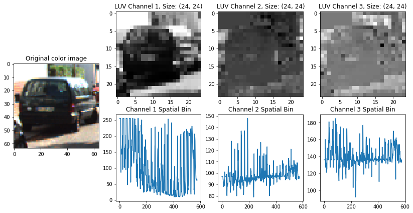

```python
visualize_bin_spatial(image,colorspace,spatial_size)
```

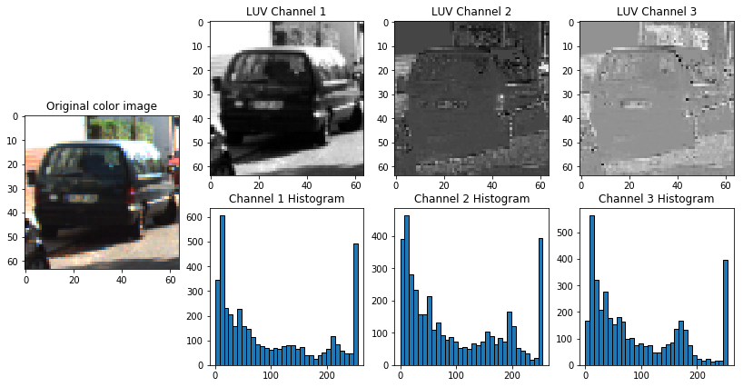

```python
visualize_color_hist(image,colorspace,32)
```

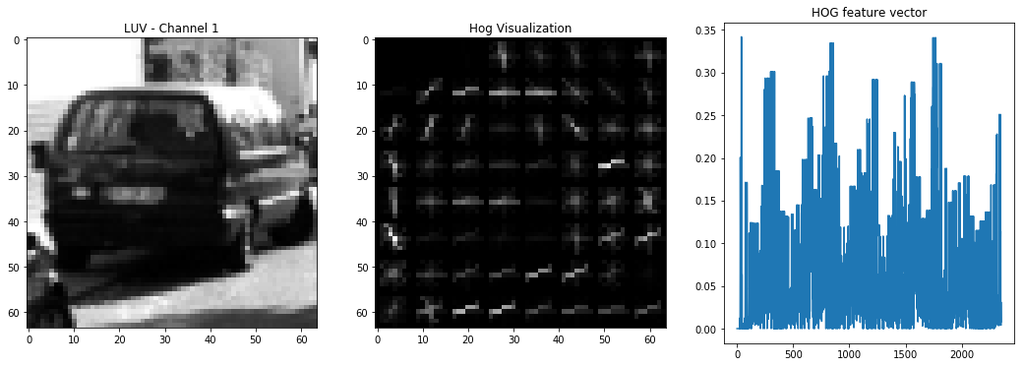

```python
visualize_hog(image,hog_colorspace,hog_channel)
```

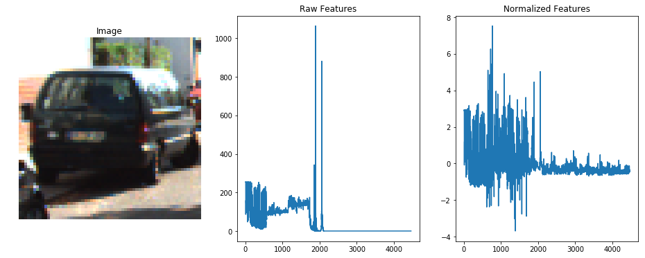

```python
f=NewFigure(16,6)
ax=DisplaySub(f,1,3,1,image,title='Image')
plt.subplot(1,3,2)
plt.plot(X[car_ind])
plt.title('Raw Features')
plt.subplot(1,3,3)
plt.plot(scaled_X[car_ind])
plt.title('Normalized Features')
plt.show()
```

### Visualization of extracted features for notcar class

```python
#notcar_ind = np.random.randint(0, len(notcar_features))
notcar_ind = 821
image=cv2.imread(notcars[notcar_ind])
image=cv2.cvtColor(image,cv2.COLOR_BGR2RGB)
```

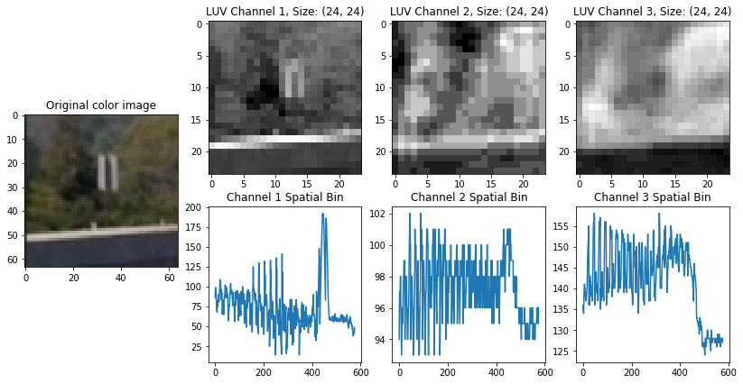

```python
visualize_bin_spatial(image,colorspace,spatial_size)
```

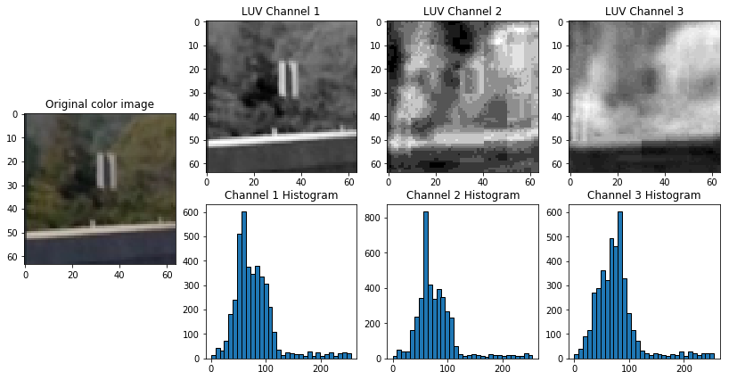

```python
visualize_color_hist(image,colorspace,32)
```

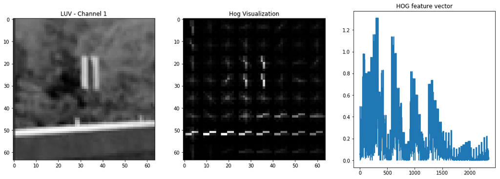

```python
visualize_hog(image,hog_colorspace,hog_channel)
```

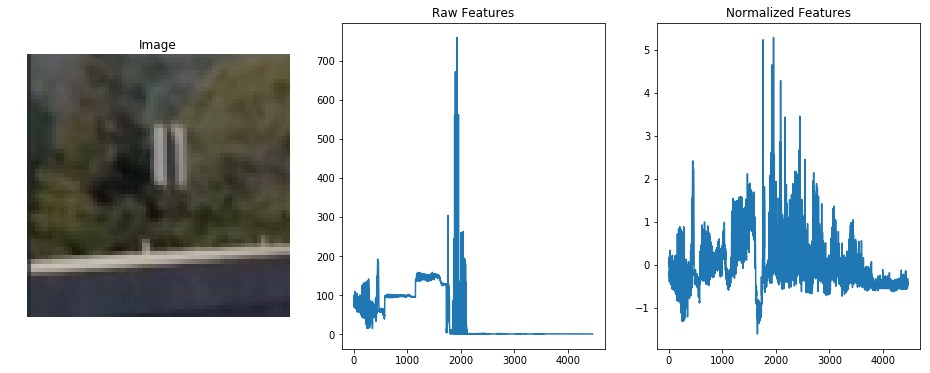

```python
f=NewFigure(16,6)
ax=DisplaySub(f,1,3,1,image,title='Image')
plt.subplot(1,3,2)
plt.plot(X[notcar_ind+len(cars)])
plt.title('Raw Features')
plt.subplot(1,3,3)
plt.plot(scaled_X[notcar_ind+len(cars)])
plt.title('Normalized Features')
plt.show()
```

### Perform stratified shuffle split to separate the data into training and test sets

```python
# Split up data into randomized training and test sets
#rand_state = np.random.randint(0, 100)
rand_state = 32
sss=StratifiedShuffleSplit(n_splits=1, test_size=0.2, random_state=rand_state)
for train_index, test_index in sss.split(scaled_X, y):
    X_train, X_test = scaled_X[train_index], scaled_X[test_index]
    y_train, y_test = y[train_index], y[test_index]
```

### Train a linear SVM classifier

```python
def maybe_gridsearchcv(filename, model, X, y, params,force=False):
    if os.path.exists(filename) and not force:
        # You may override by setting force=True.
        print('%s already present - Skipping model tuning. Loading pickle file instead.' \
              % (filename))
        try:
            print('Loading %s ...' % (filename))
            with open(filename, 'rb') as f:
                data = pickle.load(f)
                grid_obj = data['grid_obj']
                timeElapsed = data['timeElapsed']
            print('Loading done.')
        except Exception as e:
            print('Unable to extract data from', filename, ':', e)

    else:
        t=time.time()
        grid_obj = GridSearchCV(model,params,cv=5,scoring='accuracy')
        grid_obj = grid_obj.fit(X, y)
        t2 = time.time()
        timeElapsed=round(t2-t, 2)
        data={}
        data['grid_obj']=grid_obj
        data['timeElapsed']=timeElapsed
        try:
            with open(filename, 'wb') as f:
                pickle.dump(data, f, pickle.HIGHEST_PROTOCOL)
            print('Pickling done.')
        except Exception as e:
            print('Unable to save data to',  filename, ':', e)
    return grid_obj, timeElapsed
```

```python
pos_weight=len(car_features)/total_samples
neg_weight=(len(notcar_features)+len(hard_neg_features))/total_samples
svc = LinearSVC(C=1.0,class_weight={0:neg_weight,1:pos_weight})

parameters={'C': [0.1,0.5,1.0,5.0,10.0]}
filename='gridsearch_svc.p'
grid_obj, timeElapsed = maybe_gridsearchcv(filename, svc,
                                           X_train, y_train,
                                           parameters,force=False)

print(timeElapsed, 'seconds to tune the model.')

df=pd.DataFrame(grid_obj.cv_results_)
df1=df[['param_C','mean_train_score','mean_test_score']]
display(HTML(df1.to_html(index=True)))
```

```
gridsearch_svc.p already present - Skipping model tuning. Loading pickle file instead.
Loading gridsearch_svc.p ...
Loading done.
339.15 seconds to tune the model.
```

|  | param_C | mean_train_score | mean_test_score |
| --- | --- | --- | --- |
| 0 | 0.1 | 1.0 | 0.983974 |
| 1 | 0.5 | 1.0 | 0.983613 |
| 2 | 1 | 1.0 | 0.983553 |
| 3 | 5 | 1.0 | 0.983553 |
| 4 | 10 | 1.0 | 0.983553 |

```python
pos_weight=len(cars)/total_samples
neg_weight=(len(notcars)+len(hard_neg_features))/total_samples

print('Using:',orient,'orientations',pix_per_cell,
    'pixels per cell and', cell_per_block,'cells per block')
print('Feature vector length:', len(X_train[0]))
print()
# Use a linear SVC
svc = LinearSVC(C=grid_obj.best_estimator_.C,
                class_weight={0:neg_weight,1:pos_weight})
svc.fit(X_train, y_train)
print("Final model:")
print(svc)
print()

# Check the score of the SVC
print('Test Accuracy of SVC = ', round(svc.score(X_test, y_test), 4))
print()
# Check the prediction time for a single sample
t=time.time()
n_predict = 10
print('My SVC predicts: ', svc.predict(X_test[0:n_predict]))
print('For these',n_predict, 'labels: ', y_test[0:n_predict])
t2 = time.time()
print(round(t2-t, 5), 'seconds to predict', n_predict,'labels with SVC')
```

```
Using: 12 orientations 8 pixels per cell and 2 cells per block
Feature vector length: 4464

Final model:
LinearSVC(C=0.1, class_weight={0: 0.5778353980601172, 1: 0.42216460193988287},
     dual=True, fit_intercept=True, intercept_scaling=1,
     loss='squared_hinge', max_iter=1000, multi_class='ovr', penalty='l2',
     random_state=None, tol=0.0001, verbose=0)

Test Accuracy of SVC =  0.983

My SVC predicts:  [ 0.  0.  0.  1.  0.  1.  0.  0.  1.  1.]
For these 10 labels:  [ 0.  0.  0.  1.  0.  1.  0.  0.  1.  1.]
0.00257 seconds to predict 10 labels with SVC
```

```python
def save_model(model,filename):
    data={}
    data['model']= model
    data['scaler']=X_scaler
    data["colorspace"]=colorspace
    data["hist_bins"]=hist_bins
    data["spatial_size"]=spatial_size
    data["hog_colorspace"]=hog_colorspace
    data["hog_channel"]=hog_channel
    data["orient"]=orient
    data["pix_per_cell"]=pix_per_cell
    data["cell_per_block"]=cell_per_block
    try:
        with open(filename, 'wb') as f:
            pickle.dump(data, f, pickle.HIGHEST_PROTOCOL)
        print('Pickling done.')
    except Exception as e:
        print('Unable to save data to',  filename, ':', e)
```

```python
save_model(svc,'svc.p')
```

```
Pickling done.
```

### Multiscale sliding window

**We will be implementing sliding window search in the image at two different scales, i.e. 1x and 2x.**

**However, instead of using window of two different sizes, we will be using the same 64x64 pixel window for both the 1x and 2x sliding window search.**

**For the 1x sliding window search, we will use the 64x64 pixel sliding window in the image at the original size. For the 2x sliding window search, we will use the 64x64 pixel sliding window in the image scaled by 0.5 in both width and height.**

```python
def multiscale_vis(image,
                   ystart, ystop,
                   xstart, xstop):
    cropped=image[ystart:ystop,xstart:xstop,:]
    imshape=cropped.shape
    f=NewFigure(14,8)
    ax=DisplaySub(f,2,1,1,cropped,axis='on')
    plt.title('Scale=1.0')
    ax.set_xlim([0,cropped.shape[1]])
    ax.set_ylim([cropped.shape[0],0])
    major_ticks_x = np.arange(0, imshape[1], 64)
    ax.set_xticks(major_ticks_x)
    major_ticks_y = np.arange(0, imshape[0], 64)
    ax.set_yticks(major_ticks_y)
    ax.grid(color='c')
    scale=2
    scaled1=cv2.resize(cropped,(np.int(imshape[1]//scale), np.int(imshape[0]//scale)))
    ax=DisplaySub(f,2,1,2,scaled1,axis='on')
    plt.title('Scale=2.0')
    ax.set_xlim([0,cropped.shape[1]])
    ax.set_ylim([cropped.shape[0],0])
    major_ticks_x = np.arange(0, imshape[1], 64)
    ax.set_xticks(major_ticks_x)
    major_ticks_y = np.arange(0, imshape[0], 64)
    ax.set_yticks(major_ticks_y)
    ax.grid(color='c')
```

**Below shows an example frame with the region of interest highlighted by a green rectangle.**

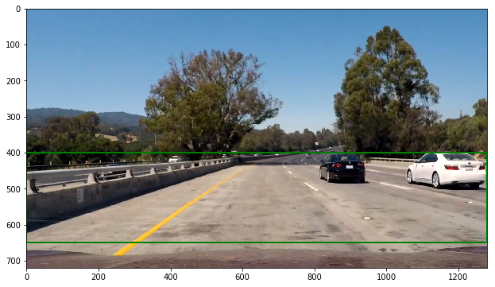

```python
image=cv2.imread('images/1005.png')
image=cv2.cvtColor(image,cv2.COLOR_BGR2RGB)

# Define ROI
ystart, ystop = 400, 650
xstart, xstop = 0, 1279
roi=Rectangle((xstart,ystart),xstop-xstart,ystop-ystart,fill=False,color='g',linewidth=2)
f=NewFigure()
ax=DisplaySub(f,1,1,1,image,axis='on')
ax.add_patch(roi)
plt.show()
```

**The following illustrates two different scale of sliding window search. The first one, scale=1 looks for smaller vehicles while the second one, scale=2 looks for larger ones.**

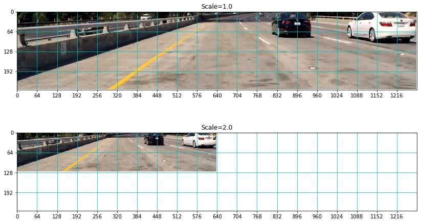

```python
multiscale_vis(image, ystart, ystop, xstart, xstop)
```

### Optimizing sliding window search

```python
def draw_sliding_windows(window, xstart, ystart, width, height):
    nx_steps=width//window
    ny_steps=height//window

    for xb in range(nx_steps):
        for yb in range(ny_steps):
            xpos = xb*window + xstart
            ypos = yb*window + ystart
            roi=Rectangle((xpos,ypos),window, window,fill=False,color='c',linewidth=2)
            ax.add_patch(roi)
```

**Due to perspective projection of the camera, we know that cars appear smaller further down the horizon of the image. Hence, we can restrict the sliding window search of scale 1 near the horizon of the image.**

**The green rectangle below represents the region where the sliding window search of scale 1 took place. The cyan rectangles are the 64x64 pixel windows with 0% overlap to illustrate the size of the window without confusion. (Note: in actual implementation, we use overlap of 75%, hence, there will be more overlapping windows that it appears here.)**

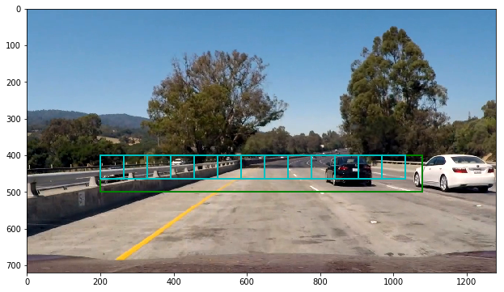

```python
ystart1, ystop1 = 400, 500
xstart1, xstop1 = 200, 1079
width1, height1 = xstop1-xstart1, ystop1-ystart1

scale1 = 1
window = 64*scale1

f=NewFigure()
ax=DisplaySub(f,1,1,1,image,axis='on')

roi1=Rectangle((xstart1,ystart1),width1, height1,fill=False,color='g',linewidth=2)
ax.add_patch(roi1)
draw_sliding_windows(window, xstart1, ystart1, width1, height1)
plt.show()
```

**Vehicles closer to the camera will appear bigger. Hence, for sliding window search of scale 2, we will place them on both sides of image, nearer to the camera.**

**The green rectangles below represent the region where the sliding window search of scale 2 took place. Similarly, the cyan rectangles are the sliding windows with zero overlap for illustration purpose only.**

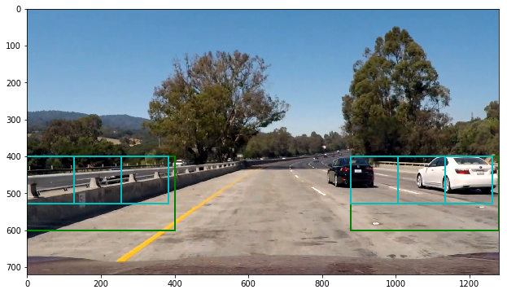

```python
ystart2, ystop2 = 400, 600
xstart2, xstop2 = 0, 400
width2, height2 = xstop2-xstart2, ystop2-ystart2
ystart3, ystop3 = 400, 600
xstart3, xstop3 = 879, 1279
width3, height3 = xstop3-xstart3, ystop3-ystart3

scale2, scale3 = 2, 2
window = 64*scale2

f=NewFigure()
ax=DisplaySub(f,1,1,1,image,axis='on')
roi2=Rectangle((xstart2,ystart2),xstop2-xstart2,ystop2-ystart2,fill=False,color='g',linewidth=2)
ax.add_patch(roi2)
draw_sliding_windows(window, xstart2, ystart2, width2, height2)

roi3=Rectangle((xstart3,ystart3),xstop3-xstart3,ystop3-ystart3,fill=False,color='g',linewidth=2)
ax.add_patch(roi3)
draw_sliding_windows(window, xstart3, ystart3, width3, height3)
plt.show()
```

### Efficient sliding window search

**In order to speed up the processing time to achieve realtime performance, it would be useful to compute the HOG features once for each frame and then perform sub-sampling from the computed HOG feature map during the sliding window search.**

**The following function 'find_cars' performs such operations and returns windows which the SVM classifier recognizes as the class 'car'.**

```python
# Define a single function that can extract features using hog sub-sampling and make predictions
def find_cars(img,
              ystart, ystop,
              xstart, xstop,
              scale,
              model, X_scaler,
              colorspace,
              hist_bins, spatial_size,
              hog_colorspace, hog_channel,
              orient, pix_per_cell, cell_per_block,
              cells_per_step=2,
              vis=False):
    if vis==True:
        draw_img = np.copy(img)

    img_tosearch = img[ystart:ystop,xstart:xstop,:]

    ctrans_tosearch = convert_color(img_tosearch, conv=colorspace)
    if hog_colorspace!=colorspace:
        hog_tosearch = convert_color(img_tosearch, conv=hog_colorspace)
    else:
        hog_tosearch = ctrans_tosearch

    if scale != 1:
        imshape = img_tosearch.shape
        ctrans_tosearch = cv2.resize(ctrans_tosearch, (np.int(imshape[1]/scale), np.int(imshape[0]/scale)))
        hog_tosearch = cv2.resize(hog_tosearch, (np.int(imshape[1]/scale), np.int(imshape[0]/scale)))

    # Define blocks and steps as above
    nxblocks = (hog_tosearch.shape[1] // pix_per_cell) - cell_per_block + 1
    nyblocks = (hog_tosearch.shape[0] // pix_per_cell) - cell_per_block + 1
    nfeat_per_block = orient*cell_per_block**2

    # 64 was the orginal sampling rate, with 8 cells and 8 pix per cell
    window = 64
    nblocks_per_window = (window // pix_per_cell) - cell_per_block + 1
    nxsteps = (nxblocks - nblocks_per_window) // cells_per_step + 1
    nysteps = (nyblocks - nblocks_per_window) // cells_per_step + 1

    # Compute individual channel HOG features for the entire image
    ch1 = hog_tosearch[:,:,0]
    ch2 = hog_tosearch[:,:,1]
    ch3 = hog_tosearch[:,:,2]
    hog1 = get_hog_features(ch1, orient, pix_per_cell, cell_per_block, feature_vec=False)
    hog2 = get_hog_features(ch2, orient, pix_per_cell, cell_per_block, feature_vec=False)
    hog3 = get_hog_features(ch3, orient, pix_per_cell, cell_per_block, feature_vec=False)
    hog=[hog1,hog2,hog3]

    matches=[]
    for xb in range(nxsteps):
        for yb in range(nysteps):
            ypos = yb*cells_per_step
            xpos = xb*cells_per_step
            # Extract HOG for this patch
            if hog_channel == "ALL":
                hog_feat1 = hog[0][ypos:ypos+nblocks_per_window, xpos:xpos+nblocks_per_window].ravel()
                hog_feat2 = hog[1][ypos:ypos+nblocks_per_window, xpos:xpos+nblocks_per_window].ravel()
                hog_feat3 = hog[2][ypos:ypos+nblocks_per_window, xpos:xpos+nblocks_per_window].ravel()
                hog_features = np.hstack((hog_feat1, hog_feat2, hog_feat3))
            else:
                hog_features = hog[hog_channel][ypos:ypos+nblocks_per_window, xpos:xpos+nblocks_per_window].ravel()

            xleft = xpos*pix_per_cell
            ytop = ypos*pix_per_cell

            # Get color features
            subimg = cv2.resize(ctrans_tosearch[ytop:ytop+window, xleft:xleft+window], (64,64))
            spatial_features = bin_spatial(subimg, size=spatial_size)
            hist_features = color_hist(subimg, nbins=hist_bins)

            # Scale features and make a prediction
            test_features = X_scaler.transform(np.hstack((spatial_features,
                                                          hist_features,
                                                          hog_features)).reshape(1, -1))
            test_prediction = model.predict(test_features)

            if test_prediction == 1:
                xleft_draw = np.int(xleft*scale)
                ytop_draw = np.int(ytop*scale)
                win_draw = np.int(window*scale)

                x1=xleft_draw+xstart
                y1=ytop_draw+ystart
                x2=x1+win_draw
                y2=y1+win_draw
                matches.append(((x1,y1),(x2,y2)))
                if vis==True:
                    cv2.rectangle(draw_img,(x1,y1),(x2,y2),(0,0,255),6)
    if vis==True:
        return matches, draw_img
    else:
        return matches
```

```python
# pix_per_cell is 8 and window size is 64 pixel,
# hence, there are 8 cell per window.
# We use step size of 2 cells for all sliding window (overlap of 6/8, i.e. 75%)
cells_per_step1 = 2
cells_per_step2 = 2
cells_per_step3 = 2

t=time.time()
found1=find_cars(image,
                ystart1, ystop1,
                xstart1, xstop1,
                scale1,
                svc, X_scaler,
                colorspace,
                hist_bins, spatial_size,
                hog_colorspace, hog_channel,
                orient, pix_per_cell, cell_per_block,
                cells_per_step=cells_per_step1)
found2=find_cars(image,
                ystart2, ystop2,
                xstart2, xstop2,
                scale2,
                svc, X_scaler,
                colorspace,
                hist_bins, spatial_size,
                hog_colorspace, hog_channel,
                orient, pix_per_cell, cell_per_block,
                cells_per_step=cells_per_step2)
found3=find_cars(image,
                ystart3, ystop3,
                xstart3, xstop3,
                scale3,
                svc, X_scaler,
                colorspace,
                hist_bins, spatial_size,
                hog_colorspace, hog_channel,
                orient, pix_per_cell, cell_per_block,
                cells_per_step=cells_per_step3)
t2=time.time()
time_elapsed=t2-t
print(time_elapsed, 'second')
```

```
0.5104691982269287 second
```

**Sliding window search output for scale = 1:**

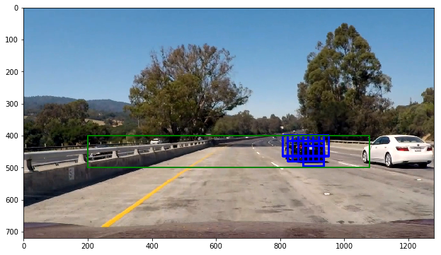

```python
draw=np.copy(image)
for (x1,y1),(x2,y2) in found1:
    cv2.rectangle(draw,(x1,y1),(x2,y2),(0,0,255),6)
f=NewFigure()
ax=DisplaySub(f,1,1,1,draw,axis='on')
roi1=Rectangle((xstart1,ystart1),width1, height1,fill=False,color='g',linewidth=2)
ax.add_patch(roi1)
plt.show()
```

**Sliding window search output for scale = 2:**

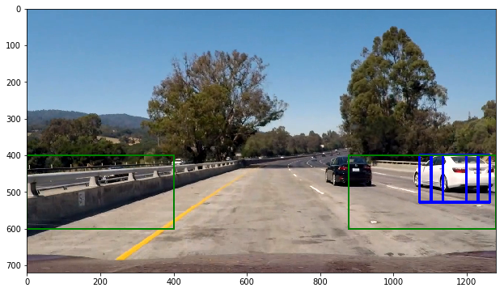

```python
draw=np.copy(image)
for (x1,y1),(x2,y2) in found2+found3:
    cv2.rectangle(draw,(x1,y1),(x2,y2),(0,0,255),6)
f=NewFigure()
ax=DisplaySub(f,1,1,1,draw,axis='on')
roi2=Rectangle((xstart2,ystart2),xstop2-xstart2,ystop2-ystart2,fill=False,color='g',linewidth=2)
ax.add_patch(roi2)
roi3=Rectangle((xstart3,ystart3),xstop3-xstart3,ystop3-ystart3,fill=False,color='g',linewidth=2)
ax.add_patch(roi3)
plt.show()
```

**Combined result of the sliding window search:**

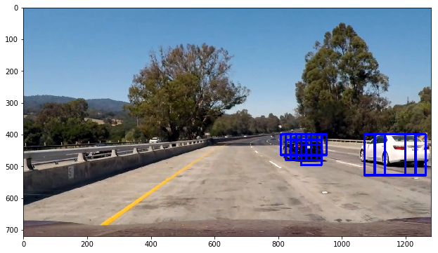

```python
found=found1+found2+found3
draw=np.copy(image)
for (x1,y1),(x2,y2) in found:
    cv2.rectangle(draw,(x1,y1),(x2,y2),(0,0,255),6)
f=NewFigure()
ax=DisplaySub(f,1,1,1,draw,axis='on')
```

### Combine overlapping detections and remove false positives

**We use the concept of a heatmap for combining overlapping detections and remove false positives. From the list of bounding boxes for the detections in the image, we add "heat" (+=1) for all pixels within windows where a positive detection is reported by the classifier.**

**The "hot" parts (high valued) of the heatmap are where the cars are, and by imposing a threshold, we can reject areas affected by false positives. Once we have a thresholded heatmap, we will use the label() function from scipy.ndimage.measurements to figure out how many cars we have in each frame and which pixels belong to which cars.**

**For each blob of thresholded heatmap, a bounding box is returned to represent the position of the detected car.**

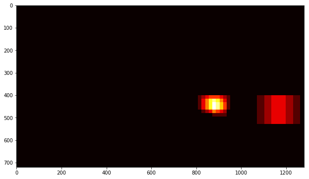

```python
def add_heat(heatmap, bbox_list):
    # Iterate through list of bboxes
    for box in bbox_list:
        # Add += 1 for all pixels inside each bbox
        # Assuming each "box" takes the form ((x1, y1), (x2, y2))
        heatmap[box[0][1]:box[1][1], box[0][0]:box[1][0]] += 1

    # Return updated heatmap
    return heatmap

heatmap=np.zeros((image.shape[0],image.shape[1]))
heatmap=add_heat(heatmap, found)
f=NewFigure()
ax=DisplaySub(f,1,1,1,heatmap,axis='on',cmap='hot')
```

```
2 cars found
```

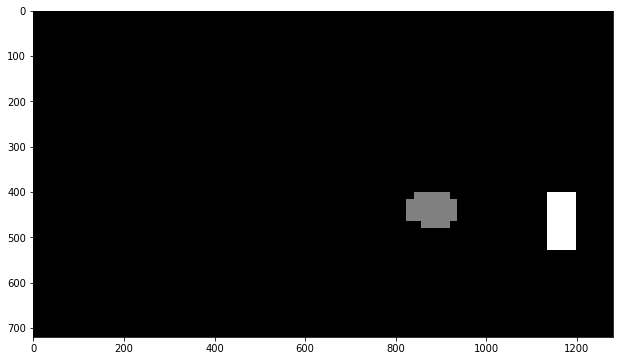

```python
def apply_threshold(heatmap, threshold):
    # Zero out pixels below the threshold
    heatmap[heatmap <= threshold] = 0
    # Return thresholded map
    return heatmap

thres=2
heatmap_thres = apply_threshold(heatmap, thres)
labels = label(heatmap_thres)
print(labels[1], 'cars found')
f=NewFigure()
ax=DisplaySub(f,1,1,1,labels[0],axis='on',cmap='gray')
```

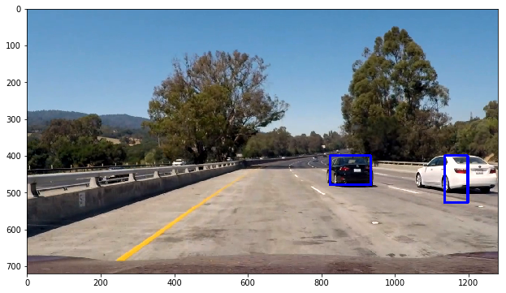

```python
def get_labeled_bboxes(img, labels):
    bboxes=[]
    # Iterate through all detected cars
    for car_number in range(1, labels[1]+1):
        # Find pixels with each car_number label value
        nonzero = (labels[0] == car_number).nonzero()
        # Identify x and y values of those pixels
        nonzeroy = np.array(nonzero[0])
        nonzerox = np.array(nonzero[1])
        # Define a bounding box based on min/max x and y
        x = np.min(nonzerox)
        y = np.min(nonzeroy)
        w = np.max(nonzerox) - x
        h = np.max(nonzeroy) - y
        bbox = (x,y,w,h)
        bboxes.append(bbox)
    # Return the image
    return bboxes

def draw_bboxes(img, bboxes):
    for bbox in bboxes:
        # Draw the box on the image
        cv2.rectangle(img,
                      (bbox[0], bbox[1]),
                      (bbox[2]+bbox[0], bbox[3]+bbox[1]),
                      (0,0,255), 6)
    # Return the image
    return img

bboxes = get_labeled_bboxes(np.copy(image), labels)
draw_img = draw_bboxes(np.copy(image), bboxes)
f=NewFigure()
ax=DisplaySub(f,1,1,1,draw_img,axis='on')
```

### Video implementation

**The project video is a video file with frame rate of 25 fps. However, for our purpose of realtime vehicle detection, it is not necessary to have such fine resolution in time since human capability in recognizing vehicles during driving also cannot reach this level.**

**For practical reasons, we will only process the video at frame rate of 5 fps by taking every fifth frame of the video stream. For intermediate frames, we will visualize them with the result from the last processed frame.**

**In addition, to further reduce the false positives, smoothing of detected bounding boxes across multiple frames is implemented. Heatmap from the last 8 processed frames are stored and an average heatmap is computed. The averaged heatmap is then thresholded at value of 1.3.**

```python
# Define a class to store the heatmap result from last n frame
class HeatObject():
    def __init__(self, n=5):
        self.iter = 0
        # n iterations to keep
        self.n = n
        # heatmap deque list
        self.heat = deque()
        # last result
        self.last_output = []
```

```python
def process_image(im):
    if heatObj.iter%5 == 0:
        found1=find_cars(im,
                        ystart1, ystop1,
                        xstart1, xstop1,
                        scale1,
                        svc, X_scaler,
                        colorspace,
                        hist_bins, spatial_size,
                        hog_colorspace, hog_channel,
                        orient, pix_per_cell, cell_per_block,
                        cells_per_step=cells_per_step1)
        found2=find_cars(im,
                        ystart2, ystop2,
                        xstart2, xstop2,
                        scale2,
                        svc, X_scaler,
                        colorspace,
                        hist_bins, spatial_size,
                        hog_colorspace, hog_channel,
                        orient, pix_per_cell, cell_per_block,
                        cells_per_step=cells_per_step2)
        found3=find_cars(im,
                        ystart3, ystop3,
                        xstart3, xstop3,
                        scale3,
                        svc, X_scaler,
                        colorspace,
                        hist_bins, spatial_size,
                        hog_colorspace, hog_channel,
                        orient, pix_per_cell, cell_per_block,
                        cells_per_step=cells_per_step3)
        found=found1+found2+found3
        heatmap=np.zeros((im.shape[0],im.shape[1]))
        heatmap=add_heat(heatmap, found)

        heatObj.heat.append(heatmap)
        if (heatObj.iter//5 >= heatObj.n):
            heatObj.heat.popleft()

        heat_cummulated=np.zeros_like(heatObj.heat[0])
        for h in heatObj.heat:
            heat_cummulated+=h
        heat_average = heat_cummulated.astype(np.float64) / len(heatObj.heat)

        heatmap_thres = apply_threshold(heat_average, thres)

        labels = label(heatmap_thres)
        bboxes = get_labeled_bboxes(im, labels)
        heatObj.last_output = bboxes
    else:
        bboxes = heatObj.last_output
    result = draw_bboxes(np.copy(im),bboxes)

    heatObj.iter += 1
    return result
```

```python
## You may also uncomment the following line for a subclip of the first 5 seconds
#clip = VideoFileClip('project_video.mp4').subclip(11,16)
clip = VideoFileClip('project_video.mp4')

thres = 1.3
heatObj = HeatObject(n=8)
clip_processed = clip.fl_image(process_image)
outputPath = 'project_video_out.mp4'
%time clip_processed.write_videofile(outputPath, audio=False)
```

```
[MoviePy] >>>> Building video project_video_out.mp4
[MoviePy] Writing video project_video_out.mp4
```

```
[MoviePy] Done.
[MoviePy] >>>> Video ready: project_video_out.mp4

CPU times: user 2min 7s, sys: 2.09 s, total: 2min 9s
Wall time: 2min 15s
```

```python
HTML("""
<video width="960" height="540" controls>
  <source src="{0}">
</video>
""".format(outputPath))
```

[video not shown]